# Analysis of power generation across USA in 2021

Srishti Mutha, Sokna Kry, Samriddha Ghosh, Nagarajan Vaidya Subramanian

Spring 2023

### Rationale and Research Questions

The US has been transitioning towards a greater reliance on renewable energy sources such as wind, solar, hydro power and many more technologies. Analyzing the e-Grid data can provide insights into the distribution of clean energy generation across US, performance of these renewable energy sources, their impact on the electricity generation and energy markets throughout USA, and whether they are meeting the expectations of energy companies, policymakers, and consumers.

This project aims to use e-GRID 2021 (published January 2023) to answer the following research questions:

1. What is the distribution of electricity generation across the Bureau of Economic Analysis regions in the US, from both the renewable and non-renewable energy sources?
2. What is the distribution of generation from each type of renewable and non-renewable energy sources across Bureau of Economic Analysis regions in the US?
3. Greenhouse gas emissions across Bureau of Economic Analysis regions in the US from electricity generators.
4. Summary statistics of generators across the Bureau of Economic Analysis regions in the US, in terms of fuel source, nameplate capacity, annual net generation, and pollutants emitted?
5. Is there correlation between energy generators and pollutants emitted?

These analyses will be performed by aggregating the states into categories as done by the Bureau of Economic Analysis which divides the states into 8 regions. We have added an additional “Non-Contiguous” category to represent states in the e-GRID dataset that are not part of mainland USA.

### Dataset Information

The Emissions & Generation Resource Integrated Database (e-GRID) is a comprehensive source of data published by the Environment Protection Agency of the US Government. This database describes various technical and environmental parameters of all electric power plants in the US, and is published annually. It includes emissions, emission rates, generation, heat input, resource mix, and many other attributes. eGRID is typically used for greenhouse gas registries and inventories, carbon footprints, consumer information disclosure, emission inventories and standards, power market changes, and avoided emission estimates.In our project we have used the e-Grid 2021 data-set which was released on January 30th, 2023.

Below are some summary statistics of the installed capacity and annual generation per region, pollutants and their CO2 equivalents per region, and lastly about the distribution of annual generation across different renewable and non-renewable sources of energy.

### Analysis

#### Question 1: What is the distribution of electricity generation across the Bureau of Economic Analysis regions in the US, from both the renewable and non-renewable energy sources?

The first research question focuses on the distribution of electricity generation from renewable and non-renewable energy sources among the Bureau of Economic Analysis (BEA) regions in the United States. The BEA divides the United States into eight regions, which are:

1. New England
2. Mideast
3. Great Lakes
4. Plains
5. Southeast
6. Southwest
7. Rocky Mountain
8. Far West

The purpose of this question is to gain a deeper understanding of the power production in different regions of the US and the types of energy sources used. This data can aid policymakers and analysts in identifying potential opportunities to increase the use of renewable energy sources and decrease reliance on non-renewable sources, such as coal and natural gas, which are known to contribute to greenhouse gas emissions and climate change. Additionally, the data can assist companies and investors in locating potential markets for renewable energy products and services.

In order to determine the distribution of electricity generation across the BEA regions in the USA, the states were grouped together based on their respective regions. The state-wise annual electricity generation was aggregated to obtain the region-wise annual generation. To better visualize and compare the electricity generation across different regions, we graphed the data in bar plots.

Figure 1: Distribution of Energy Sources by Region in 2021

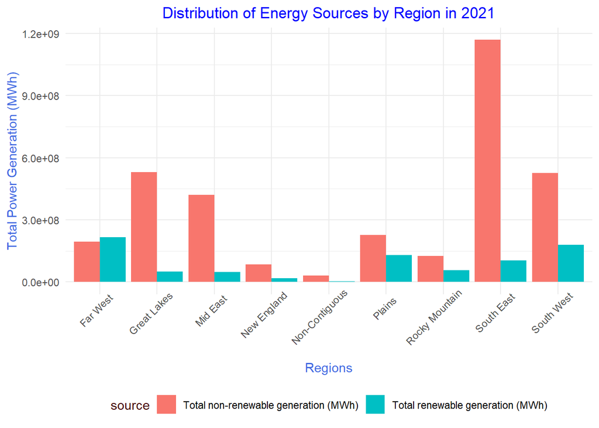

#### Question 2: What is the distribution of generation from each type of renewable energy sources across Bureau of Economic Analysis regions in the US?

The second research question looks deeper into the distribution of electricity generation from each type of renewable energy source across the BEA regions of the US. Renewable energy sources include solar, wind, hydro, geothermal, and biomass.

The purpose of this question is to gain a better understanding of how different regions in the United States are utilizing various renewable energy sources for electricity generation. The data obtained can be useful in identifying the potential for growth in the use of renewable energy sources in certain regions and identifying areas where investments in renewable energy infrastructure and technology may be needed. It can be crucial data for policymakers to develop policies and regulations that encourage the growth of specific renewable energy across USA. The potential opportunities for growth and expansion of renewable energy plants into regions that have high potential can also be evaluated using this data. Additionally, this information can be useful for identifying regions where investments in renewable energy infrastructure could be profitable.

In order to determine the distribution of electricity generation from each type of renewable energy sources across BEA regions in the US, the states were grouped together based on their respective regions. The state annual generation values for each type of renewable source were aggregated to obtain the annual electricity generation. This enabled us to obtain the total electricity generation for each type of renewable energy source for each region, annually.

Figure 2: Distribution of different renewable energy generation sources across BEA regions of USA in 2021

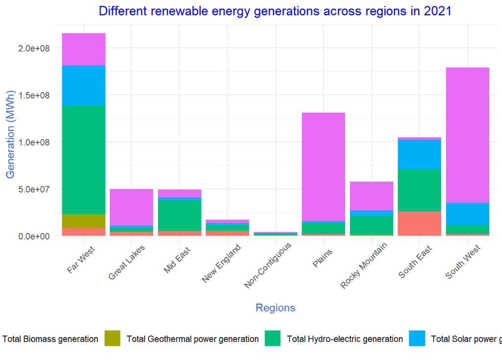

Different renewable energy generations across regions in 2021

#### Question 3: Greenhouse gas emissions across Bureau of Economic Analysis regions in the US from electricity generators.

This question delves into greenhouse gas emissions from electricity generators across the BEA regions in the US. Greenhouse gases, such as carbon dioxide, methane, nitrous oxide, sulfur dioxide and many more are released into the atmosphere as a result of the combustion of fossil fuels for electricity generation, which contributes to climate change.

The purpose of this question is to understand the level of greenhouse gas emissions from electricity generation in each region and to identify areas where there may be opportunities to reduce greenhouse gas emissions.

Analysts can make use of this data to gain insights into the sources and levels of greenhouse gas emissions from electricity generators in each region and help in the development of strategies for reducing emissions. Policymakers across USA need this data to comprehend the necessity to develop policies and regulations that encourage the transition to clean energy sources and the reduction of greenhouse gas emissions from electricity generators, such as carbon pricing or cap-and-trade programs. This information is also crucial to identify regions where investments in renewable energy infrastructure, technology and operations may impact the environment.

Figure 3: Plot of total CO2 and CO2e emissions across BEA regions of USA in 2021

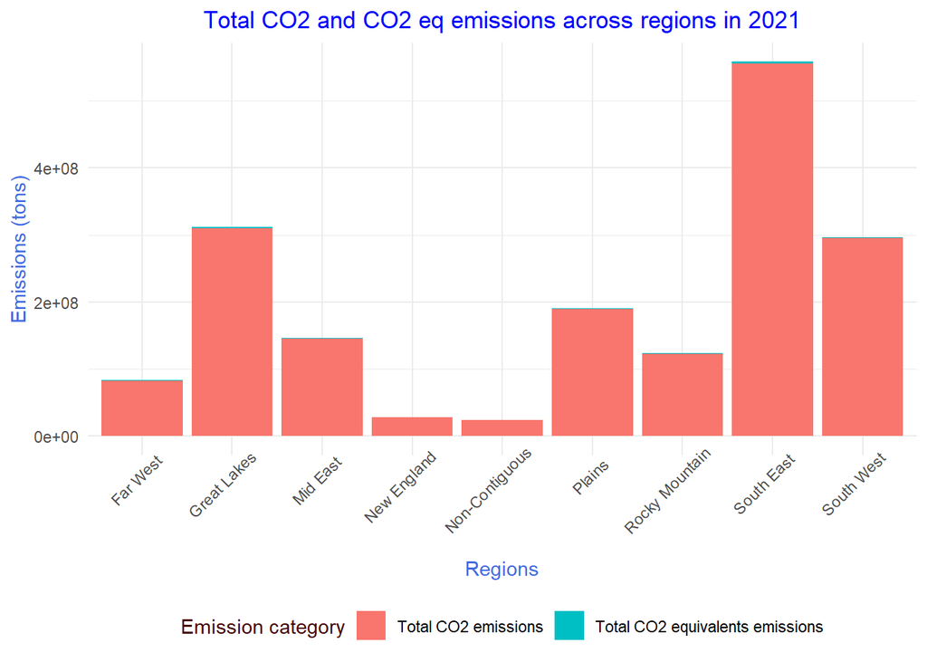

Total CO2 and CO2 eq emissions across regions in 2021

#### Question 4: Summary statistics of generators across the Bureau of Economic Analysis regions in the US, in terms of fuel source, nameplate capacity, annual net generation, and pollutants emitted

The summary statistics on electricity generators across the BEA regions in the United States covers information such as the type of fuel source used, the nameplate capacity of the generators, the annual net generation of electricity, and the amount of pollutants emitted. We performed some statistical analyses to obtain more insights. Boxplots are used for summary statistics of this question as they are the most appropriate visualization to understand the distribution of annual net generation of electricity in different regions and the pollutants. They provide a reliable way to compare medians, ranges, spread of data, and identify potential outliers, and are more effective at communicating this information than violin plots or scatter plots.

Looking at the plots for each region, we can see that the highest median of pollutants is in the Great Lakes region, while the lowest is in New England. Additionally, there is a potential outlier in the data for the South West region.

Figure 4: Carbon dioxide emissions in each BEA region in the USA in 2021

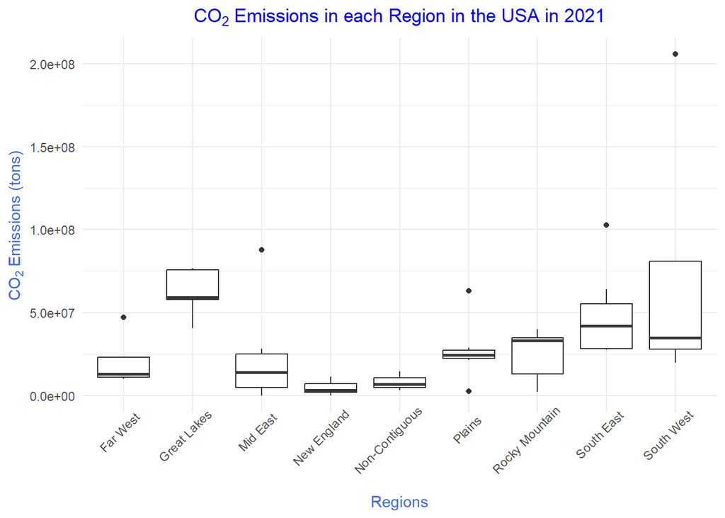

Figure 5: Sulfur dioxide emissions in each BEA region in the USA in 2021

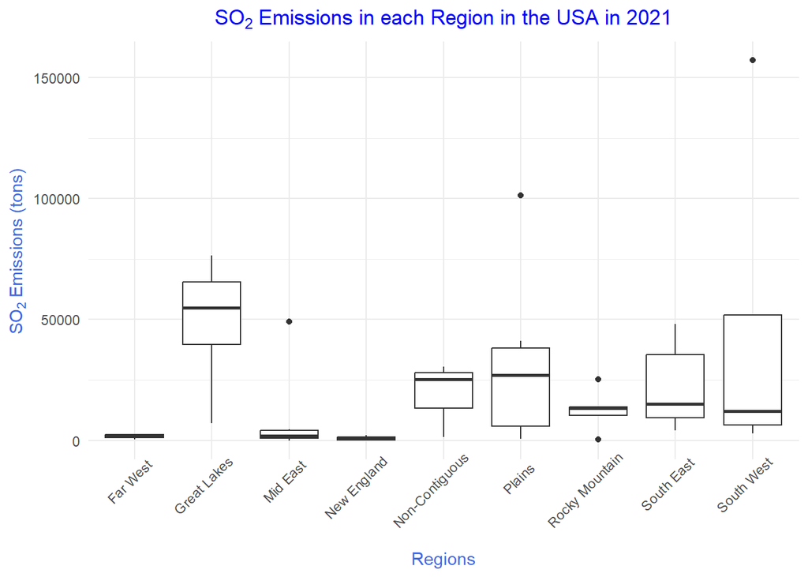

Figure 6: Nitrogen oxide emissions in each BEA region in the USA in 2021

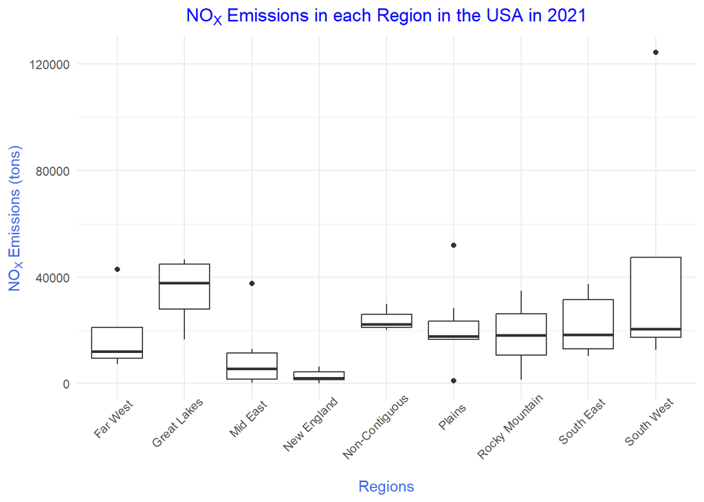

Figure 7: Carbon dioxide equivalent emissions in each BEA region in the USA in 2021

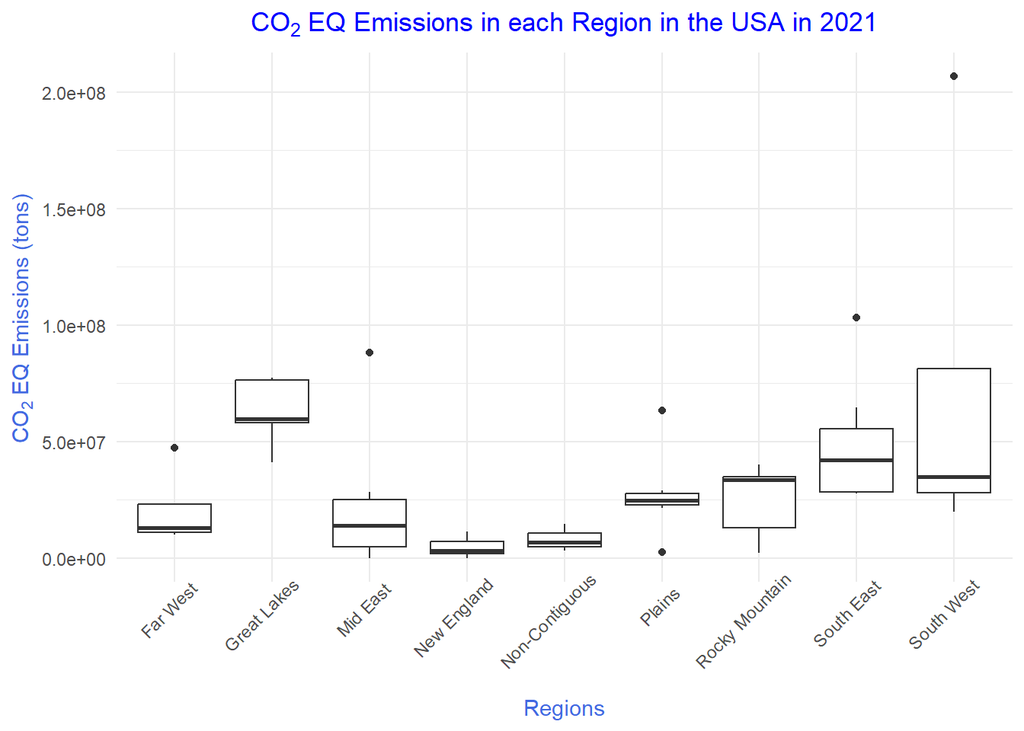

#### Question 5: Is there correlation between energy generators and pollutants emitted?

We wanted to understand the correlation between electricity generation and the quantity of different pollutants that are emitted. First, we developed linear regression models to understand the impact that electricity generation has on the emissions of different pollutants (so four linear regression models with one explanatory variable each). The type of fuel source used by a generator affects the amount and type of pollutants that are emitted during power generation. Power plants that use non-renewable fuels such as coal, oil, and natural gas emit pollutants such as carbon dioxide, methane, sulfur dioxide, nitrogen oxides, and many more, majorly contribute to climate change and air pollution.

Through this question we try to find this correlation between energy generators and the pollutants they emit. The information can be used to inform policy decisions related to reducing harmful emissions, such as setting emissions standards or incentives to increase the use of cleaner energy sources. It can also be useful for businesses to evaluate the environmental impact of their operations and to identify opportunities to reduce their carbon footprint. Understanding the correlation between energy generators and pollutants emitted can provide insights into the environmental impact of different types of energy sources and can be used by energy analysts in models for predicting future emissions trends.

The hypotheses for our models are as follows: $H_o$: There is no correlation between energy generation and pollutants emitted. $H_a$: There is some correlation between energy generation and pollutants emitted.

The four models all had a p-value of <0.001 indicating that the models had some explanatory power. We can therefore reject the null hypothesis for all four models and conclude that there is some correlation between energy generation and pollutants emitted.

Our models had different R2 values though. Annual electricity generation is able to explain 63% of the variance in NO<sub>x</sub> emissions and only under 42% of $SO_2$ emissions. Whereas it explains 82% of the variance in emissions of $CO_2$ and $CO_2$-equivalents. Further, the $\beta$ coefficients for the first two models (between electricity generation and $NO_x$ or $SO_2$) are of the order of $10^{-4}$ indicating a very small influence of electricity generation on the quantity of pollutants emitted. Whereas the $\beta$ coefficients for the last two models (between electricity generation and $CO_2$ or $CO_2$-equivalents) are of the order of $10^{-1}$ indicating that electricity generation has a 1000-fold greater impact on $CO_2$ emissions than it does on the other pollutants we looked at.

```
##
## Call:
## lm(formula = STNOXAN ~ STNGENAN, data = egrid_subset)
##
## Residuals:
##    Min     1Q Median     3Q    Max
## -19700  -7770  -2885   7305  31513
##
## Coefficients:
##              Estimate Std. Error t value Pr(>|t|)
## (Intercept) 5.260e+03  2.389e+03   2.202   0.0323 *
## STNGENAN    1.959e-04  2.125e-05   9.220  2.3e-12 ***
## ---
## Signif. codes:  0 '***' 0.001 '**' 0.01 '*' 0.05 '.' 0.1 ' ' 1
##
## Residual standard error: 12220 on 50 degrees of freedom
## Multiple R-squared:  0.6296, Adjusted R-squared:  0.6222
## F-statistic:    85 on 1 and 50 DF,  p-value: 2.3e-12
```

```
## [1] "************************************************************"
```

```
##
## Call:
## lm(formula = STSO2AN ~ STNGENAN, data = egrid_subset)
##
## Residuals:
##    Min     1Q Median     3Q    Max
## -47341 -12377  -5099  13227  80726
##
## Coefficients:
##              Estimate Std. Error t value Pr(>|t|)
## (Intercept) 2.342e+03  4.443e+03   0.527      0.6
## STNGENAN    2.361e-04  3.952e-05   5.974  2.4e-07 ***
## ---
## Signif. codes:  0 '***' 0.001 '**' 0.01 '*' 0.05 '.' 0.1 ' ' 1
##
## Residual standard error: 22730 on 50 degrees of freedom
## Multiple R-squared:  0.4165, Adjusted R-squared:  0.4048
## F-statistic: 35.69 on 1 and 50 DF,  p-value: 2.4e-07
```

```
## [1] "************************************************************"
```

```
##
## Call:
## lm(formula = STCO2AN ~ STNGENAN, data = egrid_subset)
##
## Residuals:
##       Min        1Q    Median        3Q       Max
## -34801066  -7155462  -2868586   4846472  37306906
##
## Coefficients:
##              Estimate Std. Error t value Pr(>|t|)
## (Intercept) 3.106e+06  2.875e+06   1.081    0.285
## STNGENAN    3.870e-01  2.557e-02  15.133   <2e-16 ***
## ---
## Signif. codes:  0 '***' 0.001 '**' 0.01 '*' 0.05 '.' 0.1 ' ' 1
##
## Residual standard error: 14710000 on 50 degrees of freedom
## Multiple R-squared:  0.8208, Adjusted R-squared:  0.8172
## F-statistic:   229 on 1 and 50 DF,  p-value: < 2.2e-16
```

```
## [1] "************************************************************"
```

```
##
## Call:
## lm(formula = STCO2EQA ~ STNGENAN, data = egrid_subset)
##
## Residuals:
##       Min        1Q    Median        3Q       Max
## -34977547  -7210908  -2931564   4817282  37582130
##
## Coefficients:
##              Estimate Std. Error t value Pr(>|t|)
## (Intercept) 3.163e+06  2.896e+06   1.092     0.28
## STNGENAN    3.886e-01  2.576e-02  15.085   <2e-16 ***
## ---
## Signif. codes:  0 '***' 0.001 '**' 0.01 '*' 0.05 '.' 0.1 ' ' 1
##
## Residual standard error: 14820000 on 50 degrees of freedom
## Multiple R-squared:  0.8199, Adjusted R-squared:  0.8162
## F-statistic: 227.5 on 1 and 50 DF,  p-value: < 2.2e-16
```

```
## [1] "************************************************************"
```

Figure 8: Linear Regression plot of Annual Net Energy Generation and CO2 emissions

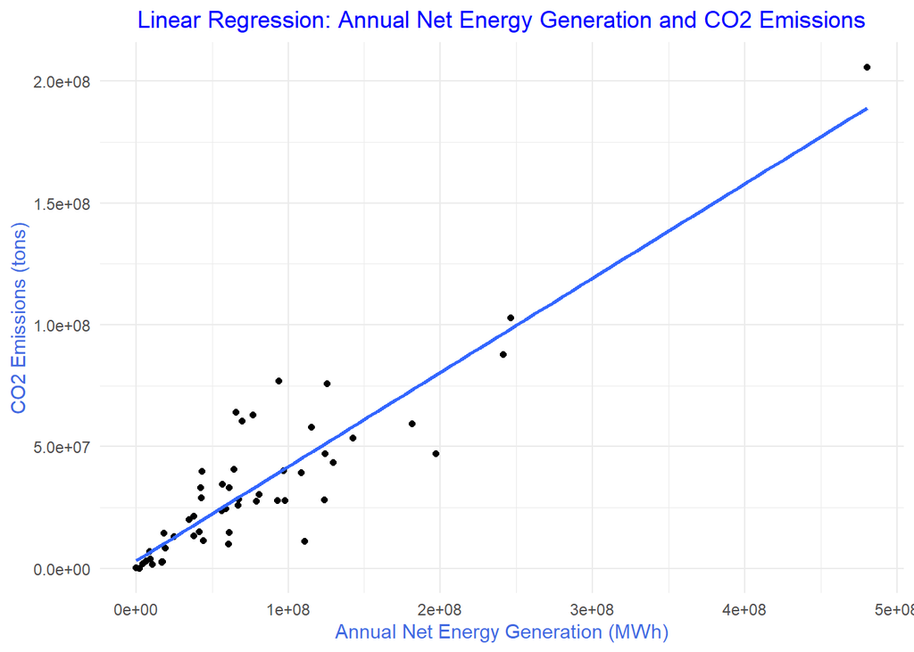

Figure 9: Linear Regression plot of Annual Net Energy Generation and CO2e emissions

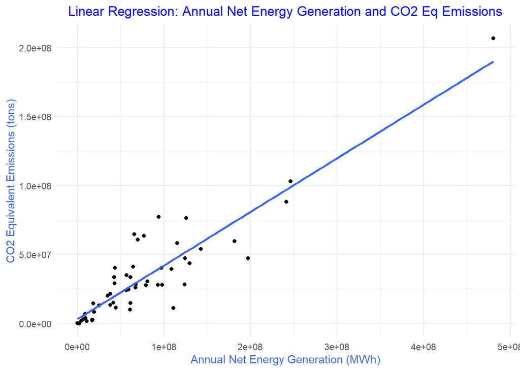

Figure 10: Linear Regression plot of Annual Net Energy Generation and SO2 emissions

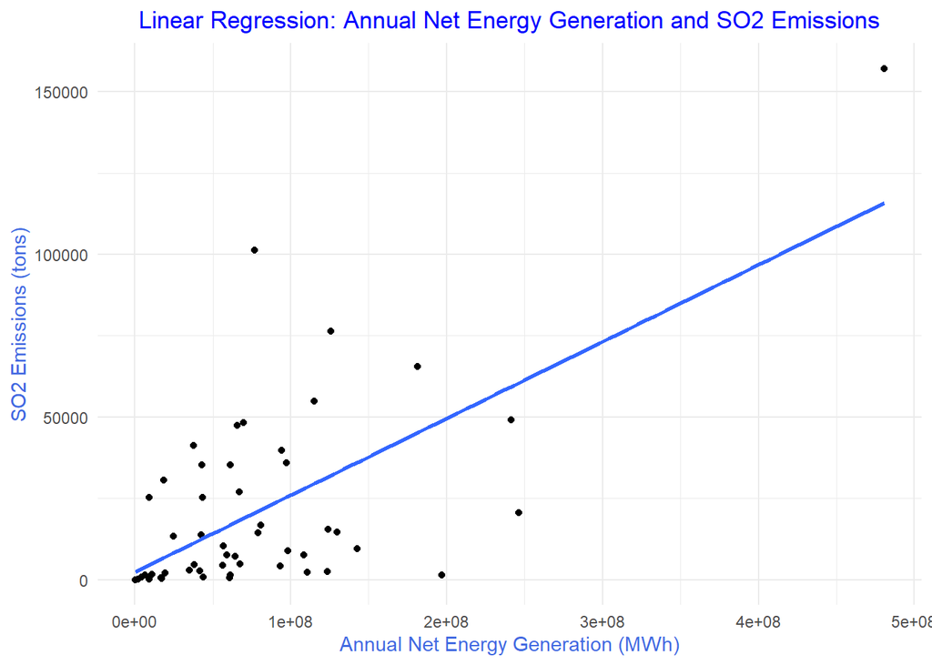

Figure 11: Linear Regression plot of Annual Net Energy Generation and NOX emissions

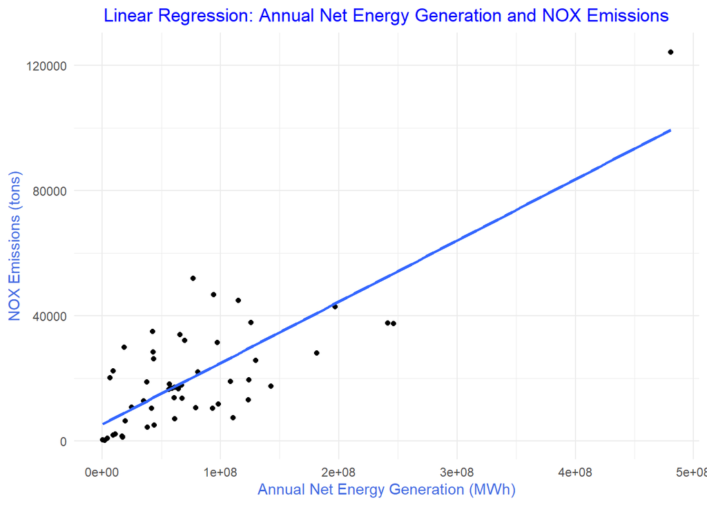

To build on this idea, we wanted to analyse the effects of different parameters on the health of people in different states, we developed three multiple linear regression models. They look at the effect that the consumption of renewable energy has on people’s health at the state level instead of the region level so as to get more granular information. We chose the following control variables: 1. air quality (which can make people vulnerable to airborne illnesses), 2. education level (which influences people’s awareness of diseases and pollutants), 3. sex ratio (to separate out the predisposition of people of different sex to have different exposures to occupational hazards), and 4. median household income (which affects people’s abilities to pay for healthcare)

Figure 12: Plot showing the correlation between explanatory and response variables for Model 1

```
##
## Call:
## lm(formula = DeathRate ~ medianAQI + medianHHI + pctRene + pctEducation +
##     SexRatio, data = dataset_final)
##
## Residuals:
##     Min      1Q  Median      3Q     Max
## -323.54  -38.26   25.17   54.24  336.93
##
## Coefficients:
##                Estimate Std. Error t value Pr(>|t|)
## (Intercept)   2.356e+03  5.572e+02   4.228 0.000114 ***
## medianAQI     5.883e+00  2.675e+00   2.199 0.033029 *
## medianHHI    -8.199e-03  1.439e-03  -5.696  8.8e-07 ***
## pctRene       7.127e+00  7.900e+01   0.090 0.928520
## pctEducation  2.259e+03  5.702e+02   3.961 0.000263 ***
## SexRatio     -1.746e+01  6.469e+00  -2.699 0.009753 **
## ---
## Signif. codes:  0 '***' 0.001 '**' 0.01 '*' 0.05 '.' 0.1 ' ' 1
##
## Residual standard error: 114.4 on 45 degrees of freedom
## Multiple R-squared:  0.6327, Adjusted R-squared:  0.5919
## F-statistic:  15.5 on 5 and 45 DF,  p-value: 7.421e-09
```

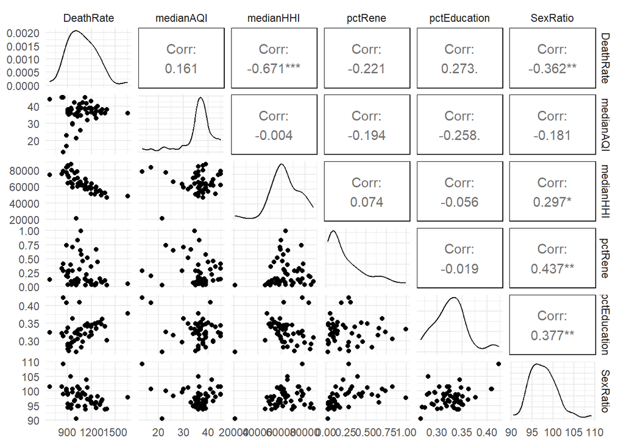

This model has an F-statistic of 15.5 on 5 variables and 45 degrees of freedom, corresponding to a p-value of <0.001. This indicates that we can reject the null hypothesis and conclude that this model has some explanatory power. This set of explanatory variables is able to explain around 63% of the variance in death rate across the US.

The correlation plot shows that we have some clustering of three explanatory variables - median AQI, percentage of total generation from renewables, and sex ratio. To improve the model we explored two transformations for these clustered variables - one being rank-transform and the other being log-transform.

Figure 13: Plot showing the correlation between explanatory and response variables for Model 2

```
##
## Call:
## lm(formula = DeathRate ~ rank_medianAQI + medianHHI + rank_pctRene +
##     pctEducation + rank_SexRatio, data = model2_subset)
##
## Residuals:
##     Min      1Q  Median      3Q     Max
## -394.49  -46.50   22.73   63.68  364.36
##
## Coefficients:
##                  Estimate Std. Error t value Pr(>|t|)
## (Intercept)     1.074e+03  2.074e+02   5.178 5.08e-06 ***
## rank_medianAQI  1.411e+00  1.147e+00   1.230 0.225110
## medianHHI      -8.574e-03  1.419e-03  -6.044 2.69e-07 ***
## rank_pctRene    5.550e-02  1.502e+00   0.037 0.970691
## pctEducation    1.912e+03  5.419e+02   3.528 0.000979 ***
## rank_SexRatio  -4.248e+00  1.585e+00  -2.680 0.010249 *
## ---
## Signif. codes:  0 '***' 0.001 '**' 0.01 '*' 0.05 '.' 0.1 ' ' 1
##
## Residual standard error: 116.6 on 45 degrees of freedom
## Multiple R-squared:  0.6186, Adjusted R-squared:  0.5762
## F-statistic:  14.6 on 5 and 45 DF,  p-value: 1.681e-08
```

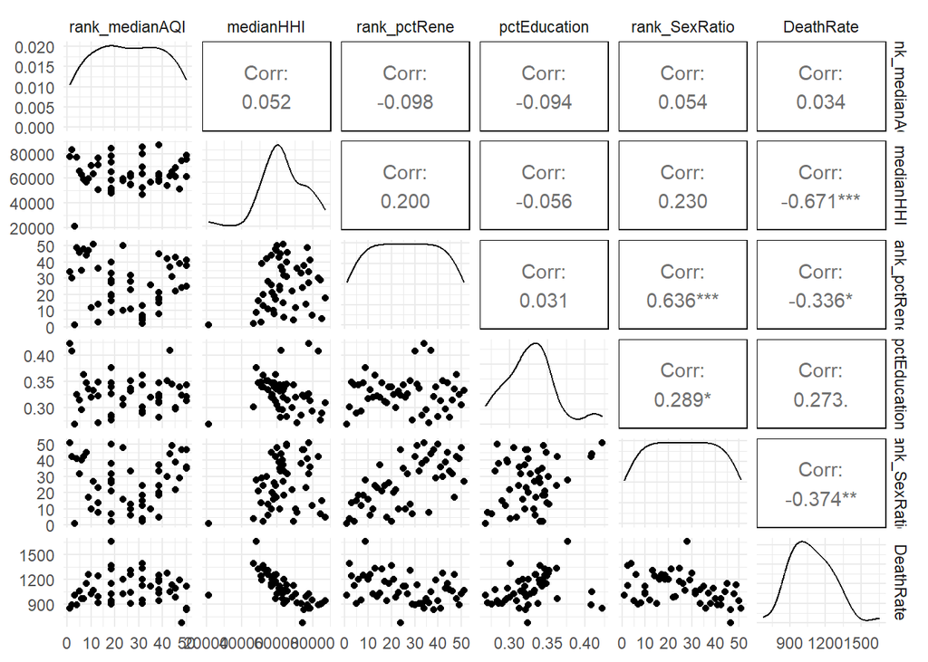

Figure 14: Plot showing the correlation between explanatory and response variables for Model 3

```
##
## Call:
## lm(formula = DeathRate ~ log_medianAQI + medianHHI + log_pctRene +
##     pctEducation + log_SexRatio, data = model3_subset)
##
## Residuals:
##     Min      1Q  Median      3Q     Max
## -304.86  -36.56   22.78   55.65  322.70
##
## Coefficients:
##                 Estimate Std. Error t value Pr(>|t|)
## (Intercept)    6.625e+03  3.123e+03   2.121 0.039445 *
## log_medianAQI  1.966e+02  7.516e+01   2.616 0.012070 *
## medianHHI     -8.122e-03  1.409e-03  -5.763 7.02e-07 ***
## log_pctRene   -8.111e+00  1.960e+01  -0.414 0.681042
## pctEducation   2.287e+03  5.634e+02   4.059 0.000194 ***
## log_SexRatio  -1.417e+03  6.903e+02  -2.053 0.045945 *
## ---
## Signif. codes:  0 '***' 0.001 '**' 0.01 '*' 0.05 '.' 0.1 ' ' 1
##
## Residual standard error: 112.5 on 45 degrees of freedom
## Multiple R-squared:  0.6449, Adjusted R-squared:  0.6055
## F-statistic: 16.35 on 5 and 45 DF,  p-value: 3.56e-09
```

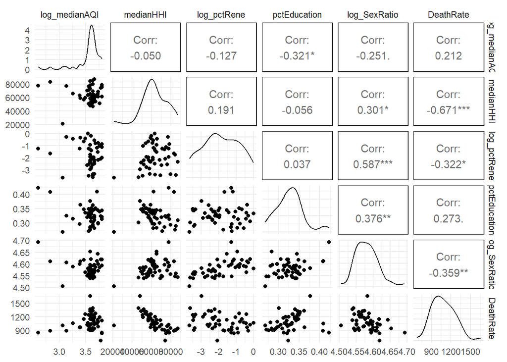

### Appendix

Table 1: Summary Statistics for Variables per Region

| Variable | Number of States | Minimum | Maximum | Mean | Median | Standard Deviation | Skewness |
| --- | --- | --- | --- | --- | --- | --- | --- |
| Far West |  |  |  |  |  |  |  |
| State annual net generation (GWh) | 4 | 40,000 | 200,000 | 100,000 | 90,000 | 69289.84 | 0.41 |
| State nameplate capacity (GW) | 4 | 10 | 90 | 40 | 20 | 33.57 | 0.65 |
| Great Lakes |  |  |  |  |  |  |  |
| State annual net generation (GWh) | 5 | 60,000 | 200,000 | 100,000 | 100,000 | 43340.70 | 0.31 |
| State nameplate capacity (GW) | 5 | 20 | 50 | 30 | 30 | 11.66 | 0.30 |
| Mid East |  |  |  |  |  |  |  |
| State annual net generation (GWh) | 6 | 200 | 200,000 | 80,000 | 50,000 | 91763.39 | 0.75 |
| State nameplate capacity (GW) | 6 | 0.05 | 50 | 20 | 20 | 21.84 | 0.35 |
| New England |  |  |  |  |  |  |  |
| State annual net generation (GWh) | 6 | 2,000 | 40,000 | 20,000 | 10,000 | 14540.51 | 0.83 |
| State nameplate capacity (GW) | 6 | 0.9 | 20 | 7 | 5 | 5.51 | 0.45 |
| Non-Contiguous |  |  |  |  |  |  |  |
| State annual net generation (GWh) | 3 | 7,000 | 20,000 | 10,000 | 9,000 | 6306.16 | 0.31 |
| State nameplate capacity (GW) | 3 | 3 | 6 | 4 | 3 | 1.84 | 0.38 |
| Plains |  |  |  |  |  |  |  |
| State annual net generation (GWh) | 7 | 20,000 | 80,000 | 50,000 | 60,000 | 20007.36 | -0.35 |
| State nameplate capacity (GW) | 7 | 7 | 20 | 20 | 20 | 7.00 | -0.19 |
| Rocky Mountain |  |  |  |  |  |  |  |
| State annual net generation (GWh) | 5 | 20,000 | 60,000 | 40,000 | 40,000 | 15952.02 | -0.07 |
| State nameplate capacity (GW) | 5 | 5 | 20 | 10 | 10 | 5.86 | 0.59 |
| South East |  |  |  |  |  |  |  |
| State annual net generation (GWh) | 10 | 60,000 | 200,000 | 100,000 | 100,000 | 51631.87 | 1.53 |
| State nameplate capacity (GW) | 10 | 20 | 70 | 30 | 30 | 15.47 | 1.42 |
| South West |  |  |  |  |  |  |  |
| State annual net generation (GWh) | 4 | 40,000 | 500,000 | 200,000 | 90,000 | 205164.83 | 0.70 |
| State nameplate capacity (GW) | 4 | 10 | 200 | 60 | 30 | 63.30 | 0.70 |

| Variable | Observations | Minimum | Maximum | Mean | Median | Standard Deviation | Skewness |
| --- | --- | --- | --- | --- | --- | --- | --- |
| Far West |  |  |  |  |  |  |  |
| State annual CO2 emissions (tons) | 4 | 10,000,000 | 50,000,000 | 20,000,000 | 10,000,000 | 17704508.67 | 0.72 |
| State annual CO2 equivalent emissions (tons) | 4 | 10,000,000 | 50,000,000 | 20,000,000 | 10,000,000 | 17756214.90 | 0.72 |
| State annual NOx emissions (tons) | 4 | 7,000 | 40,000 | 20,000 | 10,000 | 16414.69 | 0.69 |
| State annual SO2 emissions (tons) | 4 | 500 | 3,000 | 2,000 | 2,000 | 956.99 | -0.25 |
| Great Lakes |  |  |  |  |  |  |  |
| State annual CO2 emissions (tons) | 5 | 40,000,000 | 80,000,000 | 60,000,000 | 60,000,000 | 14926766.87 | -0.24 |
| State annual CO2 equivalent emissions (tons) | 5 | 40,000,000 | 80,000,000 | 60,000,000 | 60,000,000 | 15008406.43 | -0.25 |
| State annual NOx emissions (tons) | 5 | 20,000 | 50,000 | 30,000 | 40,000 | 12557.01 | -0.36 |
| State annual SO2 emissions (tons) | 5 | 7,000 | 80,000 | 50,000 | 50,000 | 26897.63 | -0.48 |
| Mid East |  |  |  |  |  |  |  |
| State annual CO2 emissions (tons) | 6 | 60,000 | 90,000,000 | 20,000,000 | 10,000,000 | 32645559.66 | 1.08 |
| State annual CO2 equivalent emissions (tons) | 6 | 60,000 | 90,000,000 | 20,000,000 | 10,000,000 | 32788416.75 | 1.08 |
| State annual NOx emissions (tons) | 6 | 300 | 40,000 | 10,000 | 6,000 | 14106.50 | 1.05 |
| State annual SO2 emissions (tons) | 6 | 3 | 50,000 | 10,000 | 2,000 | 19351.02 | 1.34 |
| New England |  |  |  |  |  |  |  |
| State annual CO2 emissions (tons) | 6 | 40,000 | 10,000,000 | 5,000,000 | 3,000,000 | 4315570.13 | 0.45 |
| State annual CO2 equivalent emissions (tons) | 6 | 50,000 | 10,000,000 | 5,000,000 | 3,000,000 | 4337858.32 | 0.45 |
| State annual NOx emissions (tons) | 6 | 200 | 6,000 | 3,000 | 2,000 | 2384.81 | 0.41 |
| State annual SO2 emissions (tons) | 6 | 20 | 2,000 | 800 | 600 | 841.65 | 0.41 |
| Non-Contiguous |  |  |  |  |  |  |  |
| State annual CO2 emissions (tons) | 3 | 3,000,000 | 10,000,000 | 8,000,000 | 7,000,000 | 5824848.33 | 0.21 |
| State annual CO2 equivalent emissions (tons) | 3 | 3,000,000 | 10,000,000 | 8,000,000 | 7,000,000 | 5841693.80 | 0.21 |
| State annual NOx emissions (tons) | 3 | 20,000 | 30,000 | 20,000 | 20,000 | 5178.34 | 0.31 |
| State annual SO2 emissions (tons) | 3 | 1,000 | 30,000 | 20,000 | 30,000 | 15476.55 | -0.34 |
| Plains |  |  |  |  |  |  |  |
| State annual CO2 emissions (tons) | 7 | 3,000,000 | 60,000,000 | 30,000,000 | 20,000,000 | 17982769.31 | 0.76 |
| State annual CO2 equivalent emissions (tons) | 7 | 3,000,000 | 60,000,000 | 30,000,000 | 20,000,000 | 18127162.28 | 0.77 |
| State annual NOx emissions (tons) | 7 | 1,000 | 50,000 | 20,000 | 20,000 | 15556.54 | 0.73 |
| State annual SO2 emissions (tons) | 7 | 600 | 100,000 | 30,000 | 30,000 | 34762.13 | 0.98 |
| Rocky Mountain |  |  |  |  |  |  |  |
| State annual CO2 emissions (tons) | 5 | 2,000,000 | 40,000,000 | 20,000,000 | 30,000,000 | 16109439.03 | -0.36 |
| State annual CO2 equivalent emissions (tons) | 5 | 2,000,000 | 40,000,000 | 20,000,000 | 30,000,000 | 16223253.72 | -0.36 |
| State annual NOx emissions (tons) | 5 | 1,000 | 30,000 | 20,000 | 20,000 | 13045.94 | -0.01 |
| State annual SO2 emissions (tons) | 5 | 500 | 30,000 | 10,000 | 10,000 | 8836.50 | 0.05 |
| South East |  |  |  |  |  |  |  |
| State annual CO2 emissions (tons) | 10 | 30,000,000 | 100,000,000 | 50,000,000 | 40,000,000 | 21985361.63 | 1.25 |
| State annual CO2 equivalent emissions (tons) | 10 | 30,000,000 | 100,000,000 | 50,000,000 | 40,000,000 | 22095901.66 | 1.25 |
| State annual NOx emissions (tons) | 10 | 10,000 | 40,000 | 20,000 | 20,000 | 9903.01 | 0.27 |
| State annual SO2 emissions (tons) | 10 | 4,000 | 50,000 | 20,000 | 10,000 | 15955.90 | 0.55 |
| South West |  |  |  |  |  |  |  |
| State annual CO2 emissions (tons) | 4 | 20,000,000 | 200,000,000 | 70,000,000 | 30,000,000 | 88321933.65 | 0.73 |
| State annual CO2 equivalent emissions (tons) | 4 | 20,000,000 | 200,000,000 | 70,000,000 | 40,000,000 | 88713493.71 | 0.73 |
| State annual NOx emissions (tons) | 4 | 10,000 | 100,000 | 40,000 | 20,000 | 53389.76 | 0.74 |
| State annual SO2 emissions (tons) | 4 | 3,000 | 200,000 | 50,000 | 10,000 | 74265.46 | 0.74 |

| Variable | Observations | Minimum | Maximum | Mean | Median | Standard Deviation | Skewness |
| --- | --- | --- | --- | --- | --- | --- | --- |
| Far West |  |  |  |  |  |  |  |
| State annual biomass net generation (GWh) | 4 | 50 | 5,000 | 2,000 | 1,000 | 2349.53 | 0.60 |
| State annual coal net generation (GWh) | 4 | 0 | 3,000 | 2,000 | 2,000 | 1625.82 | 0.01 |
| State annual gas net generation (GWh) | 4 | 20,000 | 100,000 | 40,000 | 20,000 | 38150.42 | 0.73 |
| State annual geothermal net generation (GWh) | 4 | 0 | 10,000 | 4,000 | 2,000 | 5203.54 | 0.51 |
| State annual hydro net generation (GWh) | 4 | 2,000 | 70,000 | 30,000 | 20,000 | 30244.89 | 0.49 |
| State annual nuclear net generation (GWh) | 4 | 0 | 20,000 | 6,000 | 4,000 | 7912.80 | 0.30 |
| State annual oil net generation (GWh) | 4 | 0.4 | 80 | 30 | 20 | 34.13 | 0.45 |
| State annual other fossil net generation (GWh) | 4 | 0 | 2,000 | 500 | 200 | 725.63 | 0.68 |
| State annual solar net generation (GWh) | 4 | 50 | 30,000 | 10,000 | 4,000 | 16322.85 | 0.69 |
| State annual wind net generation (GWh) | 4 | 300 | 20,000 | 9,000 | 9,000 | 6125.44 | -0.28 |
| Great Lakes |  |  |  |  |  |  |  |
| State annual biomass net generation (GWh) | 5 | 400 | 2,000 | 900 | 600 | 754.69 | 0.76 |
| State annual coal net generation (GWh) | 5 | 30,000 | 50,000 | 40,000 | 40,000 | 10057.16 | -0.13 |
| State annual gas net generation (GWh) | 5 | 20,000 | 60,000 | 30,000 | 30,000 | 14494.51 | 0.86 |
| State annual geothermal net generation (GWh) | 5 | 0 | 0 | 0 | 0 | 0.00 | NaN |
| State annual hydro net generation (GWh) | 5 | 100 | 2,000 | 800 | 600 | 791.56 | 0.91 |
| State annual nuclear net generation (GWh) | 5 | 0 | 100,000 | 30,000 | 20,000 | 38566.53 | 0.81 |
| State annual oil net generation (GWh) | 5 | 50 | 1,000 | 600 | 300 | 540.13 | 0.23 |
| State annual other fossil net generation (GWh) | 5 | 30 | 2,000 | 900 | 800 | 904.52 | 0.37 |
| State annual solar net generation (GWh) | 5 | 400 | 700 | 500 | 500 | 117.26 | 0.12 |
| State annual wind net generation (GWh) | 5 | 2,000 | 20,000 | 8,000 | 8,000 | 6966.76 | 0.65 |
| Mid East |  |  |  |  |  |  |  |
| State annual biomass net generation (GWh) | 6 | 60 | 2,000 | 800 | 500 | 827.19 | 0.37 |
| State annual coal net generation (GWh) | 6 | 0 | 30,000 | 6,000 | 700 | 11581.28 | 1.28 |
| State annual gas net generation (GWh) | 6 | 100 | 100,000 | 40,000 | 20,000 | 47806.43 | 0.89 |
| State annual geothermal net generation (GWh) | 6 | 0 | 0 | 0 | 0 | 0.00 | NaN |
| State annual hydro net generation (GWh) | 6 | −100 | 30,000 | 5,000 | 1,000 | 11279.76 | 1.33 |
| State annual nuclear net generation (GWh) | 6 | 0 | 80,000 | 30,000 | 20,000 | 28246.09 | 0.74 |
| State annual oil net generation (GWh) | 6 | 0.04 | 700 | 200 | 50 | 261.24 | 1.28 |

[output cut: 69 more lines]

### References

[Project repository on GitHub](https://github.com/Srishtimutha/EDA_Class_Project_Sp23)

1. https://en.wikipedia.org/wiki/List_of_regions_of_the_United_States
2. https://www.epa.gov/egrid/download-data
3. https://www.cdc.gov/nchs/fastats/state-and-territorial-data.htm
4. https://data.census.gov/table?t=Age+and+Sex&g=010XX00US$0400000&y=2020&tid=ACSST5Y2020.S0101&moe=false
5. https://data.census.gov/table?t=Education&g=010XX00US$0400000&y=2020&tid=ACSST5Y2020.S1501&moe=false
6. https://data.census.gov/table?t=Income+and+Poverty&g=010XX00US$0400000&y=2020&tid=ACSST5Y2020.S1901&moe=false
7. https://aqs.epa.gov/aqsweb/airdata/annual_aqi_by_county_2021.zip